# 2labtest

Рева Дарья

28 февраля 2018 г

## Считывание файла. Подготовка к кластеризации

```r
Data_begin <- read.table(file = "Data.txt", header = T, row.names = 1)
Data <- read.table(file = "Data.txt", header = T, row.names = 1)
```

Географические координаты городов на кластеризацию не влияют, поэтому удалим их из данных.

```r
Data <- Data[,-c(11,10)]
Data <- as.matrix(Data)
```

Для всех признаков, кроме трех, чем выше значение - тем лучше. Для признаков Housing и Crime - наоборот. Признак Population - объективный признак, не имеющий интерпретации как “лучше-хуже”. Так как существуют разные шкалы оценивания, данные необходимо стандартизировать.

```r
Data <- scale(Data, center = TRUE, scale = apply(Data, 2, norm, type = "2"))
```

## Необходимые функции

```r
#Объединение нескольких графиков
multiplot <- function (..., plotlist = NULL, file, cols = 1, layout = NULL) {
  library(grid)
  plots <- c(list(...), plotlist)
  numPlots = length(plots)
  if (is.null(layout)) {
    layout <- matrix(seq(1, cols * ceiling(numPlots/cols)),
      ncol = cols, nrow = ceiling(numPlots/cols))
  }
  if (numPlots == 1) {
    print(plots[[1]])
  }
  else {
    grid.newpage()
    pushViewport(viewport(layout = grid.layout(nrow(layout),
      ncol(layout))))
    for (i in 1:numPlots) {
      matchidx <- as.data.frame(which(layout == i, arr.ind = TRUE))
      print(plots[[i]], vp = viewport(layout.pos.row = matchidx$row,
        layout.pos.col = matchidx$col))
    }
  }
}

#Оптимальное количество кластеров в иерархической кластеризации
N <- nrow(Data);
clust_num<-function(f,g){
 qplot(x = seq(N-1, 1, -1),
      y = f$height,
      geom = c("point", "line"),
      xlab = "K clusters",
      ylab = "Height",
      xlim = c(0, g)
      )
}
```

## Иерархическая кластеризация

Расстояния между объектами:

- Расстояние Манхэттэнских кварталов
- Евклидово расстояние
- …

Между кластерами:

- Сomplete
- Single
- Ward
- …

Найдем Евклидово расстояние и расстояние Манхэттенских кварталов:

```r
Eucdist <- dist(Data, method = "euclidian")
Manhdist <- dist(Data, method = "manhattan")
```

Выполним кластеризацию различными методами с помощью Евклидового расстояния:

```r
hc_complete <- hclust(Eucdist, method = "complete")
hc_single <- hclust(Eucdist, method = "single")
hc_ward <- hclust(Eucdist, method = "ward.D2")
```

Выполним кластеризацию различными методами с помощью расстояния Манхэттенских кварталов:

```r
M_hc_complete <- hclust(Manhdist, method = "complete")
M_hc_single <- hclust(Manhdist, method = "single")
M_hc_ward <- hclust(Manhdist, method = "ward.D2")
```

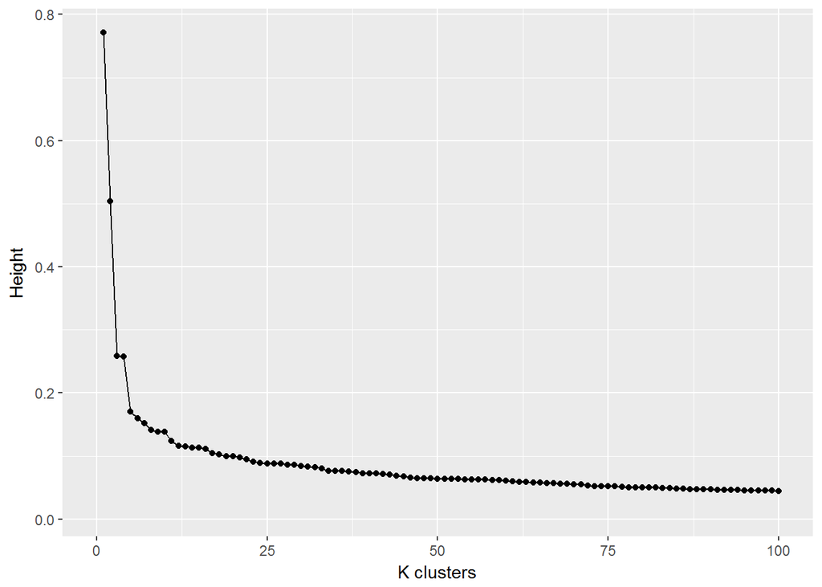

```r
clust_num(hc_complete, 100)
```

Расстояние начинает плавно убывать при переходе к 3 кластерам.

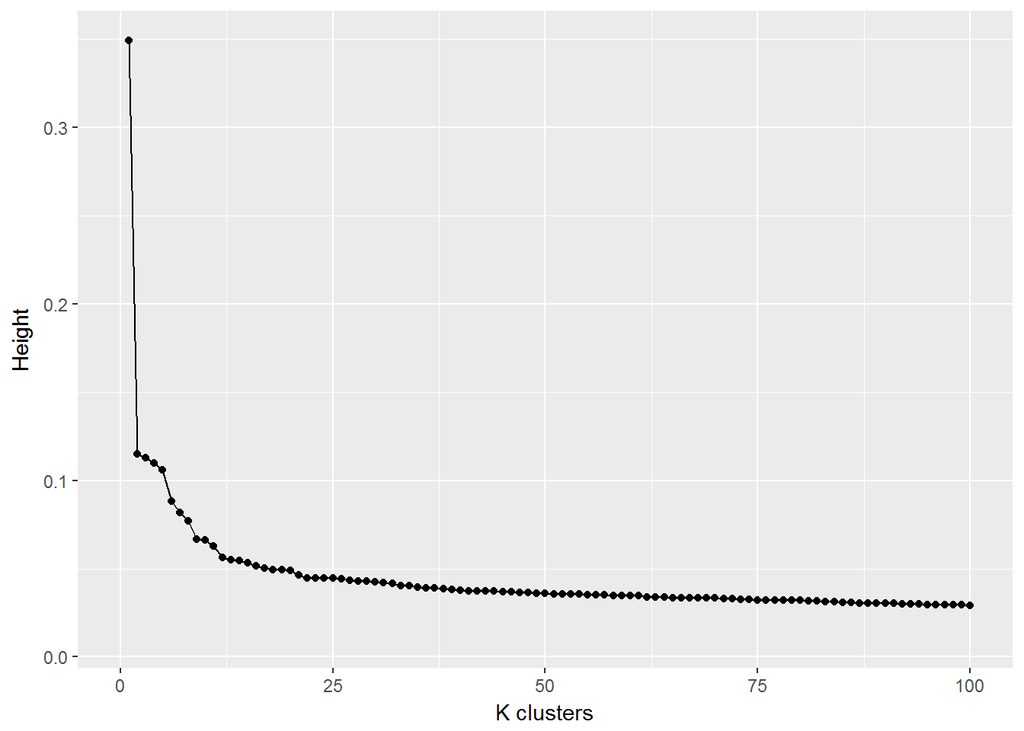

```r
clust_num(hc_single, 100)
```

Расстояние начинает плавно убывать при переходе к 2 кластерам.

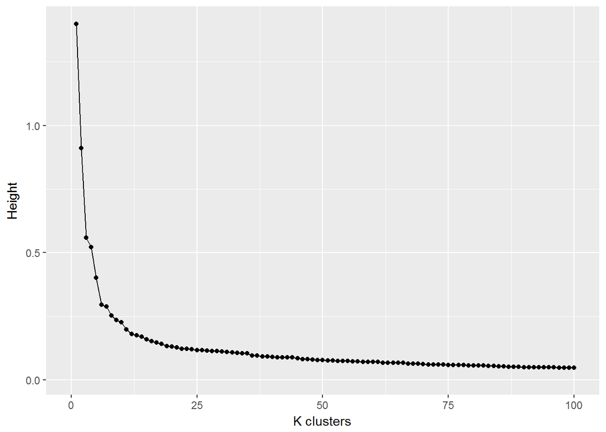

```r
clust_num(hc_ward, 100)
```

Расстояние начинает плавно убывать при переходе к 3 кластерам.

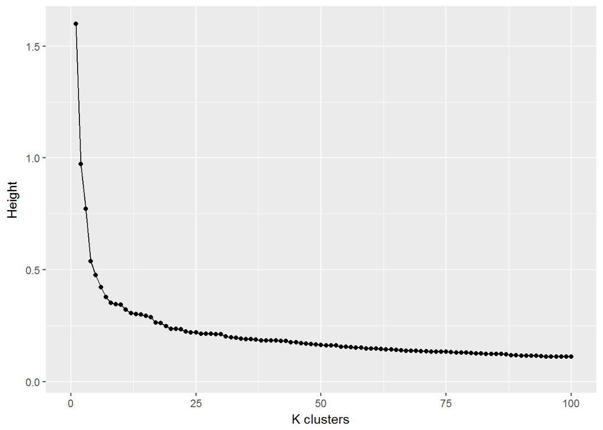

```r
clust_num(M_hc_complete, 100)
```

Расстояние начинает плавно убывать при переходе к 4 кластерам.

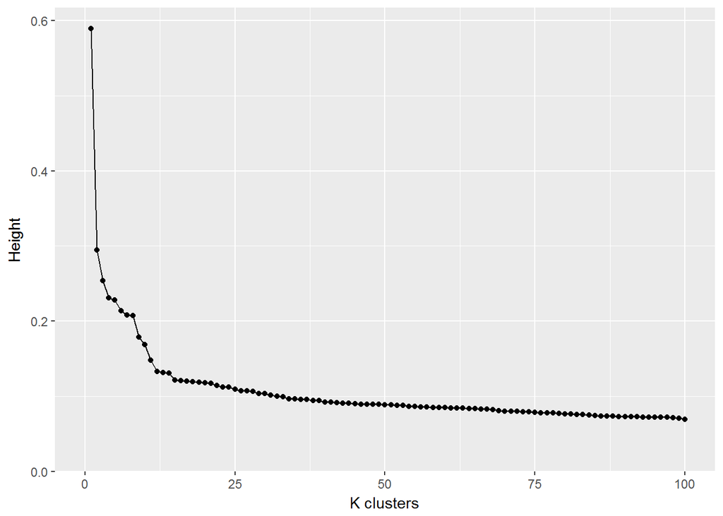

```r
clust_num(M_hc_single, 100)
```

Расстояние начинает плавно убывать при переходе к 3 кластерам.

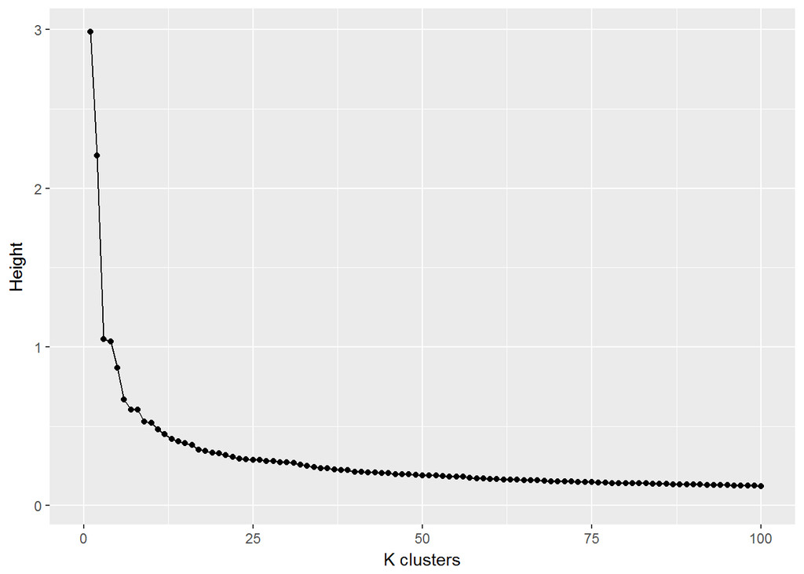

```r
clust_num(M_hc_ward, 100)
```

**ИТОГ:**Свойство монотонности соблюдается при использовании всех методов. По графикам видно, что наиболее оптимальный вариант - комбинация евклидового расстояния и метода Варда. Делим на 3 кластера, так как график перестает резко убывать при переходе к 3 кластерам.

```r
hc_clusters <- cutree(hc_ward, k = 3)
```

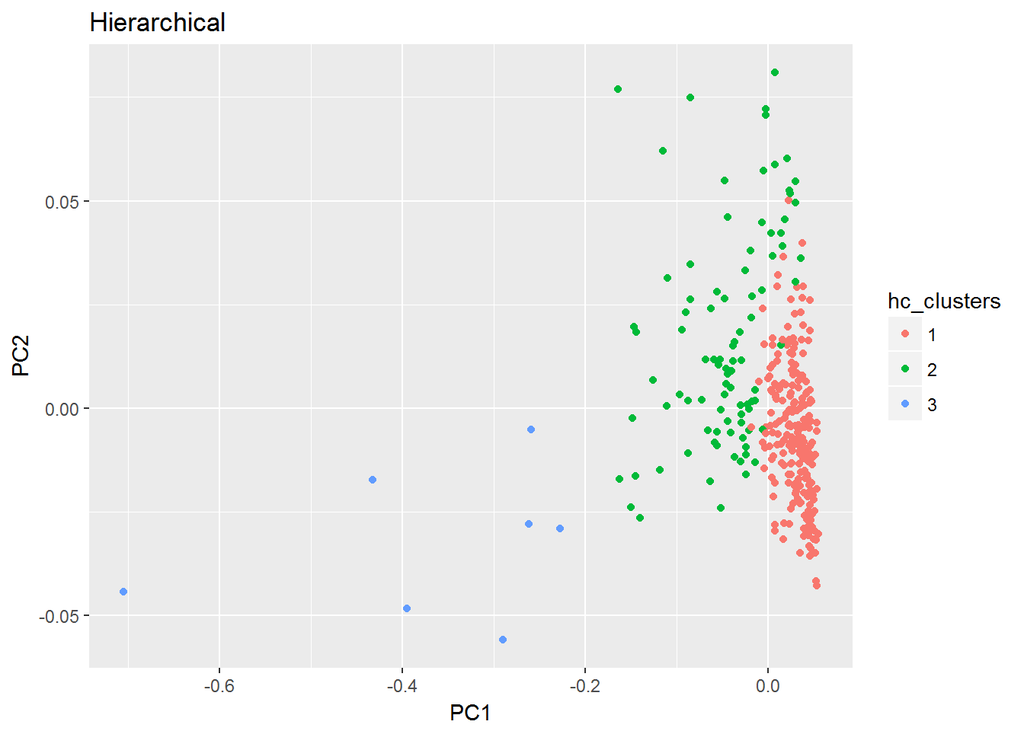

```r
#Визуализация
Data_pca <- prcomp(Data) %$%
  x[ ,1:10] %>%
  as.data.frame %>%
  cbind(.,
        hc_clusters = factor(hc_clusters))

ggplot(data = Data_pca,
                 aes(x = PC1,
                     y = PC2,
                     color = hc_clusters)) +
            geom_point() +
            ggtitle("Hierarchical")
```

## kmeans

Выполним кластеризацию kmeans. Для этого определим оптимальное число кластеров методом каменистой осыпи.

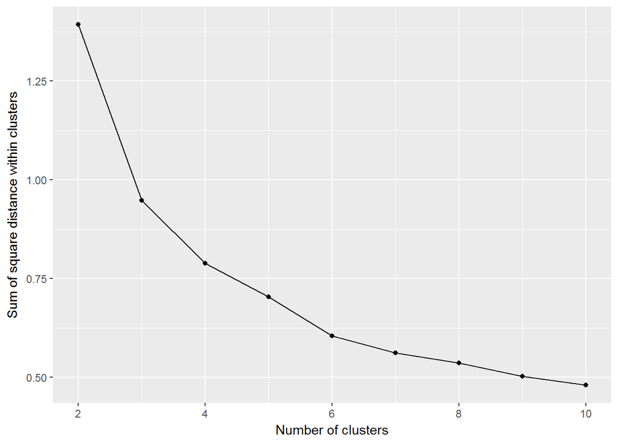

```r
D <- 2:10 %>%
  sapply(function(x){cl <- kmeans(x = Data,
                                  centers = x,
                                  nstart = 100)
                     cl$tot.withinss})
qplot(x = 2:10,
      y = D,
      geom = c("point", "line"),
      xlab = "Number of clusters",
      ylab = "Sum of square distance within clusters")
```

Из графика видно, что оптимальное число кластеров - 3 (так как в этой точке он перестает резко убывать).

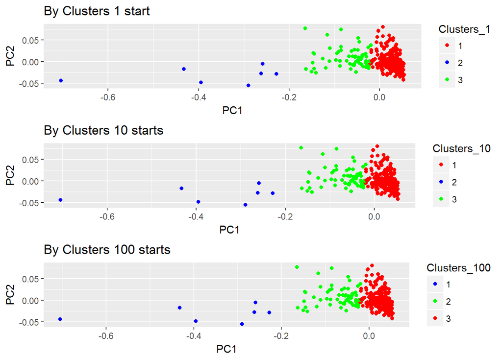

```r
#Визуализация
set.seed(100)
Data_nstart_1 <- kmeans(x = Data,
                             centers = 3,
                             nstart = 1,
                             algorithm = c("Hartigan-Wong"))

Data_nstart_10 <- kmeans(x = Data,
                              centers = 3,
                              nstart = 10,
                              algorithm = c("Hartigan-Wong"))

Data_nstart_100 <- kmeans(x = Data,
                                centers = 3,
                                nstart = 100,
                                algorithm = c("Hartigan-Wong"))

Data_pca <- Data %>%
  prcomp %$%
  x[ ,1:10] %>%
  as.data.frame %>%
  cbind(.,
        Clusters_1 = factor(Data_nstart_1$cluster),
        Clusters_10 = factor(Data_nstart_10$cluster),
        Clusters_100 = factor(Data_nstart_100$cluster))

multiplot(ggplot(data = Data_pca,
                 aes(x = PC1,
                     y = PC2,
                     color = Clusters_1)) +
            geom_point() +
            scale_color_manual(values = c('red', 'green',  'blue')[unique(Data_nstart_1$cluster)]) +
            ggtitle("By Clusters 1 start"),
          ggplot(data = Data_pca,
                 aes(x = PC1,
                     y = PC2,
                     color = Clusters_10)) +
            geom_point() +
            scale_color_manual(values = c('red', 'green',  'blue')[unique(Data_nstart_10$cluster)]) +
            ggtitle("By Clusters 10 starts"),
          ggplot(data = Data_pca,
                 aes(x = PC1,
                     y = PC2,
                     color = Clusters_100)) +
            geom_point() +
            scale_color_manual(values = c('red', 'green',  'blue')[unique(Data_nstart_100$cluster)]) +
            ggtitle("By Clusters 100 starts"),
          cols = 1)
```

Выше приведены результаты кластеризации kmeans с использованием различных количеств итераций. Разбиения повторились. То есть алгоритм нашел оптимальное разбиение с первой итерации.

```r
km_clusters <- kmeans(x = Data,
                      centers = 3,
                      nstart = 100)$cluster
```

## Partition around medoids.

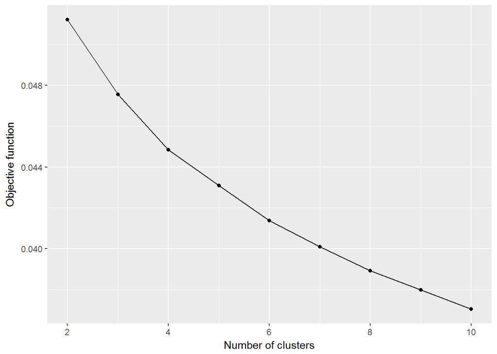

```r
D <- 2:10 %>%
sapply(function(x)
    {cl <- pam(x = Data,
                               k = x,
                               diss = FALSE,
                               metric = "euclidean",
                              stand = FALSE)
                     cl$objective[2]})
qplot(x = 2:10,
      y = D,
      geom = c("point", "line"),
      xlab = "Number of clusters",
      ylab = "Objective function")
```

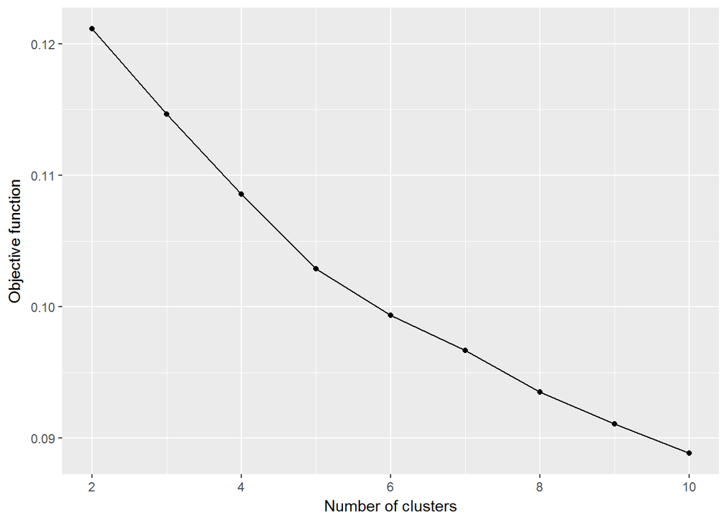

```r
D <- 2:10 %>%
sapply(function(x)
    {cl <- pam(x = Data,
                               k = x,
                               diss = FALSE,
                               metric = "manhattan",
                              stand = FALSE)
                     cl$objective[2]})
qplot(x = 2:10,
      y = D,
      geom = c("point", "line"),
      xlab = "Number of clusters",
      ylab = "Objective function")
```

```r
pam_clusters <- pam(x = Data,
                    k = 3,
                    diss = FALSE,
                    metric = "euclidean",
                    stand = FALSE)$clustering
```

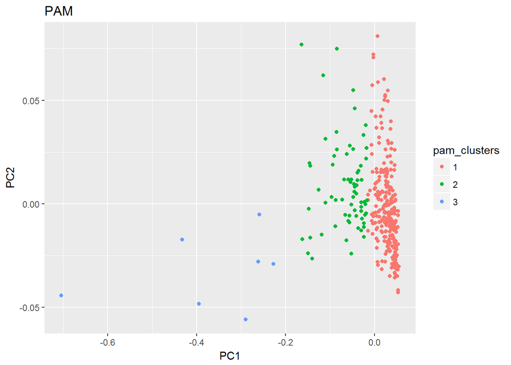

```r
#Визуализация
Data_pca <- prcomp(Data) %$%
  x[ ,1:10] %>%
  as.data.frame %>%
  cbind(.,
        pam_clusters = factor(pam_clusters))

ggplot(data = Data_pca,
                 aes(x = PC1,
                     y = PC2,
                     color = pam_clusters)) +
            geom_point() +
            ggtitle("PAM")
```

## Сравнение методов кластеризации

Теперь мы можем сравнить результаты кластеризации разными методами.

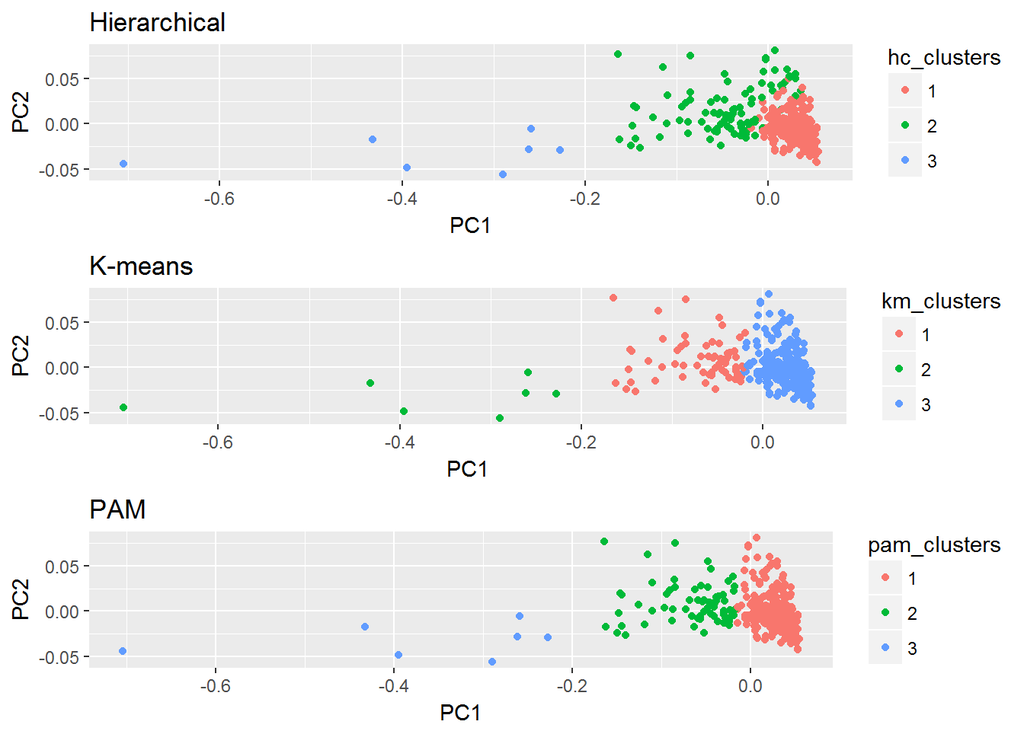

```r
#PCA
Data_pca <- prcomp(Data) %$%
  x[ ,1:2] %>%
  as.data.frame %>%
  cbind(.,
        hc_clusters = factor(hc_clusters),
        km_clusters = factor(km_clusters),
        pam_clusters = factor(pam_clusters))

multiplot(ggplot(data = Data_pca,
                 aes(x = PC1,
                     y = PC2,
                     color = hc_clusters)) +
            geom_point() +
            ggtitle("Hierarchical"),
          ggplot(data = Data_pca,
                 aes(x = PC1,
                     y = PC2,
                     color = km_clusters)) +
            geom_point() +
            ggtitle("K-means"),
          ggplot(data = Data_pca,
                 aes(x = PC1,
                     y = PC2,
                     color = pam_clusters)) +
            geom_point() +
            ggtitle("PAM"),
          cols = 1)
```

Разбиения практически совпали. Однако в PCA часть информации теряется. Построим таблицы сопряженности:

```r
table(pam_clusters, km_clusters)
```

```
##             km_clusters
## pam_clusters   1   2   3
##            1   0   0 253
##            2  64   0   5
##            3   0   7   0
```

```r
table(pam_clusters, hc_clusters)
```

```
##             hc_clusters
## pam_clusters   1   2   3
##            1 229  24   0
##            2   1  68   0
##            3   0   0   7
```

```r
table(km_clusters, hc_clusters)
```

```
##            hc_clusters
## km_clusters   1   2   3
##           1   0  64   0
##           2   0   0   7
##           3 230  28   0
```

Разбиения не совпали.

## Интерпретация кластеризации

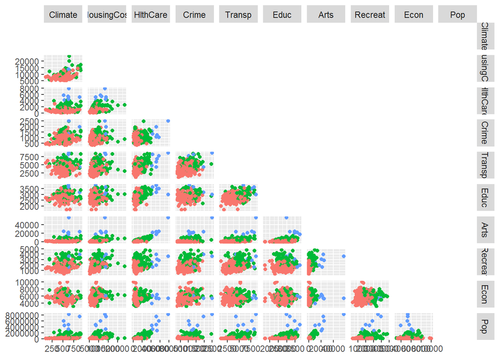

```r
#Hierarchy
Data2 <- Data_begin[,-c(11,10)]
colnames(Data_begin) <- colnames(Data2)

clusters <- factor(hc_clusters)

ggpairs(data = Data2,
aes(colour = clusters),
diag = list(continuous = 'blankDiag'),
upper = list(continuous = 'blank'))
```

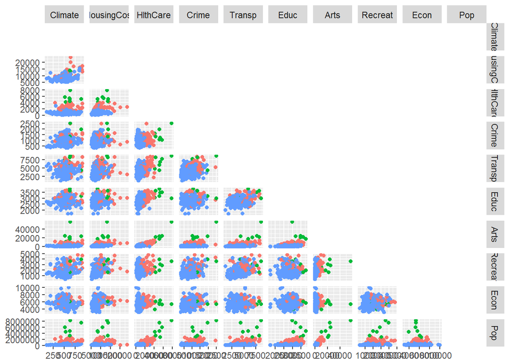

```r
#kmeans
clusters <- factor(km_clusters)

ggpairs(data = Data2,
aes(colour = clusters),
diag = list(continuous = 'blankDiag'),
upper = list(continuous = 'blank'))
```

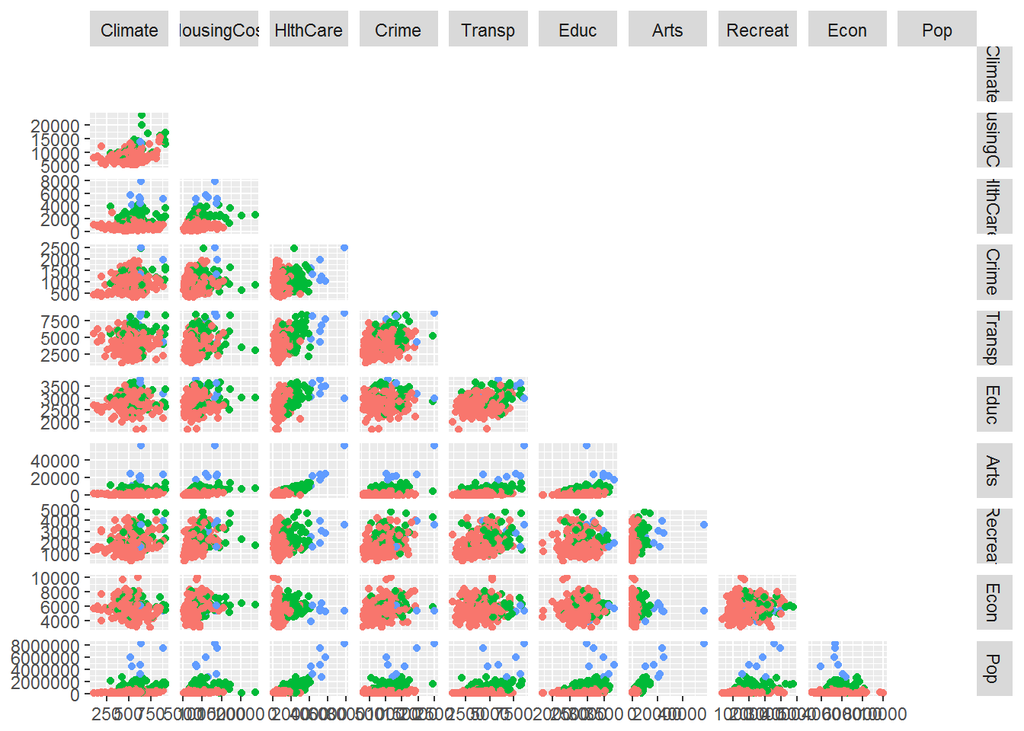

```r
#PAM
clusters <- factor(pam_clusters)

ggpairs(data = Data2,
aes(colour = clusters),
diag = list(continuous = 'blankDiag'),
upper = list(continuous = 'blank'))
```

3 кластера - подразделение городов на богатые, средние и бедные. В следующих признаках кластеры четко распределились по шкале от минимального к максимальному значению:

- Housing Cost
- Arts
- Population
- Health Care

Если интерпретировать буквально, то чем выше уровень жизни в городе, тем выше

- стоимость жилья
- уровень медицины и культурного развития
- количество населения